# Plants | Free Full-Text | Clarification of the Position of Linum stelleroides Planch. within the Phylogeny of the Genus Linum L. | HTML

Plants

[Journals](https://www.mdpi.com/about/journals)

[Plants](https://www.mdpi.com/journal/plants)

[Volume 11](https://www.mdpi.com/2223-7747/11)

[Issue 5](https://www.mdpi.com/2223-7747/11/5)

10.3390/plants11050652

[figure not shown]

## Article Menu

...

...

Open AccessArticle

# Clarification of the Position of Linum stelleroides Planch. within the Phylogeny of the Genus Linum L.

by

Nadezhda L. Bolsheva

<sup>1,*</sup>,

Nataliya V. Melnikova

<sup>1</sup>,

Ekaterina M. Dvorianinova

<sup>1,2</sup>,

Liudmila N. Mironova

<sup>3</sup>,

Olga Y. Yurkevich

<sup>1</sup>,

Alexandra V. Amosova

<sup>1</sup>,

George S. Krasnov

<sup>1</sup>,

Alexey A. Dmitriev

<sup>1,*</sup> and

Olga V. Muravenko

<sup>1</sup>

<sup>1</sup>

Engelhardt Institute of Molecular Biology, Russian Academy of Sciences, 119991 Moscow, Russia

<sup>2</sup>

Moscow Institute of Physics and Technology, 141701 Moscow, Russia

<sup>3</sup>

Botanical Garden-Institute of the Far Eastern Branch of the Russian Academy of Sciences, 690024 Vladivostok, Russia

Authors to whom correspondence should be addressed.

Academic Editors: Irina N. Anisimova, Svetlana Goryunova and Eugene Radchenko

*Plants* **2022**, *11*(5), 652; https://doi.org/10.3390/plants11050652

Received: 20 January 2022 / Revised: 21 February 2022 / Accepted: 21 February 2022 / Published: 27 February 2022

(This article belongs to the Special Issue [Genetic Resources of Cereal and Oilseed Crops for Sustainable Breeding and Food Security](https://www.mdpi.com/journal/plants/special_issues/cereal_oilseed_crops))

## Abstract

The phylogeny of members of the family Linaceae DC. ex Perleb has not been adequately studied. In particular, data on the phylogenetic relationship between Linum stelleroides Planch. and other representatives of the blue-flowered flax are very controversial. In the present work, to clarify this issue, we obtained DNA sequences of three nuclear loci (IGS and ITS1 + 5.8S rDNA + ITS2 of the 35S rRNA gene and the 5S rRNA gene) and eight chloroplast loci (rbcL, the trnL–trnF intergenic spacer, matK, the 3′ trnK intron, ndhF, trnG, the psbA–trnH intergenic spacer, and rpl16) of 10 Linum L. species (L. stelleroides, L. hirsutum, L. perenne, L. leonii, L. lewisii, L. narbonense, L. decumbens, L. grandiflorum, L. bienne (syn. L. angustifolium), and L. usitatissimum) using high-throughput sequencing data. The phylogenetic analysis showed that L. stelleroides forms a basal branch in the blue-flowered flax clade. Previously found inconsistencies in the position of L. stelleroides and some other species in the Linaceae phylogenetic tree resulted from the erroneous species identification of some of the studied plant samples.

*Keywords:* flax; [*Linum stelleroides* Planch.](https://www.mdpi.com/search?q=Linum%20stelleroides%20Planch.); phylogeny; [genome sequencing](https://www.mdpi.com/search?q=genome%20sequencing)

## 1. Introduction

Linum stelleroides Planch., an annual, wild-growing species, was named after German naturalist Georg Steller, who explored the nature of Siberia, the Far East, and Alaska. The species is distributed across the southern Far East and Eastern Siberia in Russia, China, Japan, Korea, Kyrgyzstan, Tajikistan, Turkmenistan, and Uzbekistan. Based on several morphological characteristics, L. stelleroides differs significantly from other members of the genus Linum. Notably, in L. stelleroides, the margins of the sepals are membranous, with large black stipulate glands. L. stelleroides has pantoporate pollen grains with 12 pores, whereas the members of the other three sections have tricolpate pollen, except for a few polyploid species which have polycolpate pollen [1,2]. These differences provided the basis for categorizing L. stelleroides within a separate monotypic section of Stellerolinum Juz. [1,2,3,4].

Recent molecular phylogenetic studies showed that representatives of the genus Linum are subdivided into two large sister groups. The first group comprises yellow-flowered species corresponding to sections Cathartolinum (Reichen b.) Griseb., Syllinum Griseb., and Linopsis (Reichenb.) Engelmann and genera Cliococca Bab., Hesperolinon (A. Gray) Small, Radiola Hill., and Sclerolinon C.M. Rogers. The second group includes blue-flowered flax species from sections Dasylinum (Planchon) Juz., Adenolinum (Reichenb.) Juz. (syn. L. perenne L. group), and Linum L. and L. stelleroides (monotypic sect. Stellerolinum Juz. ex Prob.) [5].

At the same time, data on the phylogenetic relationship between L. stelleroides and other representatives of the blue-flowered flax are very contradictory. In particular, several molecular phylogenetic studies indicated that L. stelleroides is closely related to representatives of the sect. Adenolinum (syn. L. perenne group) [6,7,8,9], whereas, in the rbcL phylogeny, it was a sister to the sect. Dasylinum [5]. According to a sequence-specific amplified polymorphism (SSAP) analysis and data on nuclear internal transcribed spacers (ITS), three chloroplast DNA sequences (ndhF + trnK intron + trnL-trnF spacer), and the nuclear 5S ribosomal RNA (rRNA) gene, L. stelleroides formed an independent basal clade of the blue-flowered flax [5,10,11]. Finally, combined data on ITS and seven plastid sequences (rbcL, the trnL–trnF spacer, the 3′ trnK intron, ndhF, trnG, the psbA–trnH spacer, the rpl16 intron) showed that L. stelleroides takes an intermediate position between the clusters formed by representatives of the sect. Dasylinum on the one hand, and representatives of the sect. Adenolinum on the other hand [12].

In this study, we used recent high-throughput sequencing results for several Linum species, including L. stelleroides, to determine or improve the accuracy of the DNA sequences of three nuclear loci (IGS and ITS1 + 5.8S rDNA + ITS2 sequences of the 35S rRNA gene and the 5S rRNA gene) and eight chloroplast loci (rbcL, the trnL–trnF intergenic spacer, matK, the 3′ trnK intron, ndhF, trnG, the psbA–trnH intergenic spacer, rpl16). The improved sequences were used to clarify the phylogenetic relationship between L. stelleroides and other representatives of the genus Linum.

## 2. Results

#### 2.1. Morphological Characteristics of L. stelleroides Specimens

To study the morphology of mature plants, seeds of the L. stelleroides accession LIN 1655 from the Germplasm Bank of the Leibniz Institute of Plant Genetics and Crop Plant Research, Germany (IPK) were planted in the field and grown to the stages of flowering and seed maturation. The grown LIN 1655 plants were morphologically different from L. stelleroides. Namely, LIN 1655 is perennial; its flowers are heterostylous; the petals are blue-violet; the outer sepals are 4–6 mm with a sharp apex and a narrow white scarious margin; the inner sepals are wider and slightly longer than the outer ones with a rounded apex and entire scarious margins; capsules are 5–6 mm long and 4–5 mm wide, subglobose, with a very short beak; and the seeds are quite large, i.e., 3.0–3.5 mm in length and dark brown in color (Figure 1a–d). According to botanical descriptions [3,4], L. stelleroides is an annual; its flowers are ~1 cm in diameter; its petals are pink-violet, sometimes blue-violet, and rarely white; the sepals are 3–5 mm long and rounded ovate with a sharp apex; the sepal margins are narrowly bordered with characteristic sessile rounded black glands of a rather large size; capsules are acuminate, subglobose, 4–5 mm long and 4–5 mm wide; and the seeds are rather small, i.e., ~2 mm in length and brown colored.

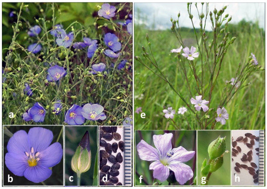

**Figure 1.** Photo of plants of the LIN 1655 accession (**a**–**d**) and L. stelleroides specimen from the Far East of Russia (**e**–**h**). **a**,**e**—general view of plants; **b**,**f**—flower morphology; **c**,**g**—calyx morphology; **d**,**h**—seeds, scale 1 mm. Photo of L. stelleroides in its natural habitat near the Kraskino village kindly provided by Dr. Z.V. Kozhevnikova.

Thus, in terms of morphological characteristics, the LIN 1655 accession is similar to species of the L. perenne group, but not L. stelleroides. Moreover, the morphological features of the L. stelleroides specimen collected in the Far East of Russia correspond completely to those described at the end of the previous paragraph (Figure 1e–h).

#### 2.2. Assembling Sequences

At the initial stage of our work, sequences of 11 loci (IGS and ITS1 + 5.8S rDNA + ITS2 of the 35S rRNA gene, the 5S rRNA gene, rbcL, the trnL–trnF intergenic spacer, matK, the 3′ trnK intron, ndhF, trnG, the psbA–trnH intergenic spacer, and rpl16) were assembled from whole-genome sequencing (WGS) data for 12 flax species: L. stelleroides, L. hirsutum, L. perenne, L. narbonense, and L. usitatissimum (NCBI BioProject PRJNA497747, our data) and L. leonii, L. lewisii, L. decumbens, L. grandiflorum, L. bienne (syn. L. angustifolium), L. strictum, and L. arboreum (PRJNA262458). The resulting sequences were compared with the corresponding ones from NCBI GenBank, previously obtained by sequencing of cloned PCR amplicons in several studies. All the assembled sequences for L. usitatissimum, L. bienne, L. decumbens, L. narbonense, L. perenne, L. leonii, L. lewisii, and L. hirsutum turned out to be highly homologous (homology level >98%) to the sequences of the same or closely related species from GenBank. At the same time, a small number of single nucleotide substitutions, deletions, or insertions in polymorphic loci were observed.

For the L. stelleroides and L. grandiflorum species, the assembled rbcL, trnL–trnF intergenic spacer, 3’ trnK intron, ndhF, and ITS sequences were highly homologous to the ones listed in GenBank for the same species (homology level ~99%). However, the homology between the corresponding sequences of trnG, the psbA–trnH intergenic spacer, and rpl16 was significantly lower (<90%). At the same time, trnG, the psbA–trnH intergenic spacer, and rpl16 sequences presented in GenBank for L. stelleroides and L. grandiflorum appeared to be highly homologous (>99%) to the sequences of the same loci for members of the sect. Adenolinum. Notably, for the sequences of rbcL, the trnL–trnF intergenic spacer, the 3’ trnK intron, ndhF, and ITS, such a high homology between L. stelleroides or L. grandiflorum and sect. Adenolinum members was not observed, suggesting that a mistake in the identification of species of plant specimens was made in the course of earlier sequencing of trnG, the psbA–trnH intergenic spacer, and rpl16 of L. stelleroides and L. grandiflorum.

For all the analyzed loci of L. strictum (sect. Linopsis) and L. arboreum (sect. Syllinum), we revealed a low level of homology between the sequences presented in GenBank and those assembled from WGS reads in this study. At the same time, the assembled L. strictum sequences were highly homologous (>99%) to those of the corresponding loci of sect. Adenolinum members deposited in GenBank. The sequences of chloroplast loci assembled from genomic reads of L. arboreum showed low homology to the GenBank sequences of both this and other species of the family Linaceae. We could not assemble the ITS1 + 5.8S rDNA + ITS2 fragment of the 35S rRNA gene for L. arboreum using the reference from GenBank. Therefore, we had to use the Repeat Explorer 2 toolkit and obtained the fragment showing <40% homology to similar sequences of members of the genus Linum and significant homology (99%) to the ITS1 + 5.8S rDNA + ITS2 sequence of Alyssoides utriculata (L.) Medikus (Brassicaceae), accession KF022514 in NCBI GenBank. These results gave strong reasons to doubt the correctness of the species identification of the sequenced L. strictum and L. arboreum accessions. Therefore, the sequences of these two species assembled from WGS reads were excluded from further phylogenetic analysis. The results of assembling the sequences of the studied loci for the remaining 10 flax species are presented in Supplementary Tables S1–S11.

#### 2.3. Phylogenetic Analysis

Based on GenBank data for the sequences of 11 loci for 40 plant species and the updated sequences of the same loci assembled from WGS reads for the other 10 species of flax, Maximum Likelihood (ML) and Bayesian phylogenetic trees of Linoideae were constructed (Figure 2 and Figure 3). The performed phylogenetic analysis showed that L. stelleroides represents an independent branch in the phylogenetic tree of Linaceae, occupying the basal position inside the clade of the blue-flowered flax. The divergence of the L. stelleroides ancestor from the common trunk of the blue-flowered flax clade occurred approximately 33.5 million years ago (Figure 4). Then, species of sections Dasylinum, Adenolinum, and Linum branched off from their common trunk. The basal branch of the yellow-flowered flax clade is represented by Radiola linoides Roth. Then, branches of species of sections Cathartolinum, Syllinum, and Linopsis diverged from the basal one. The sect. Linopsis split into three clades—one of them is represented by species of the New World, and the other two— species of the Old World with the main chromosome number equal to 9 (L. setaceum, L. strictum, L. volkensii, L. suffruticosum, L. tenuifolium) and 10 (L. maritimum, L. trigynum, L. tenue).

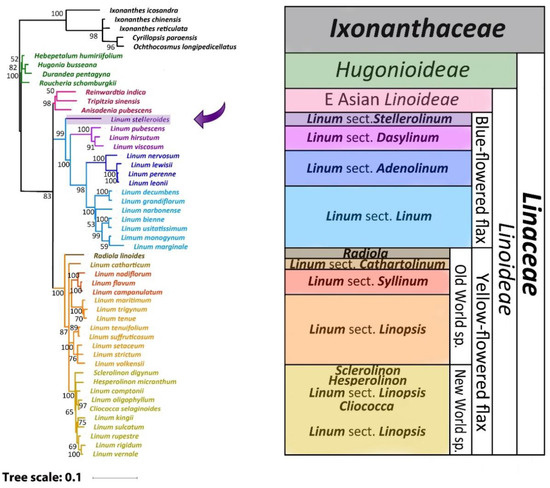

**Figure 2.** Maximum likelihood (ML) phylogeny of 11 loci of 45 Linaceae taxa and the selected outgroup of 5 Ixonanthaceae taxa. The values shown above or below branches are the node supports assessed by bootstrap values. The position of L. stelleroides is marked with an arrow.

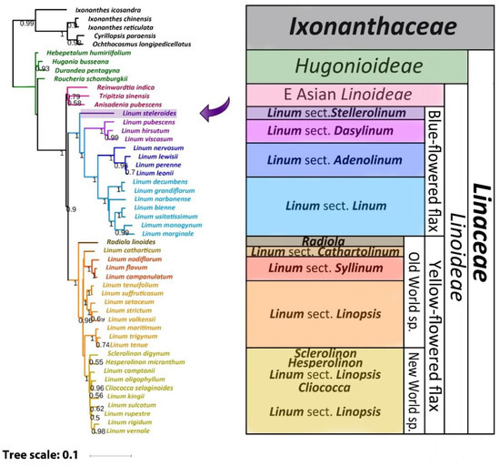

**Figure 3.** Bayesian phylogeny of 11 loci of 45 Linaceae taxa and the selected outgroup of 5 Ixonanthaceae taxa. The values shown above or below branches are the node supports assessed by the Bayesian-like modification of the approximate likelihood ratio test (aBayes). The position of L. stelleroides is marked with an arrow.

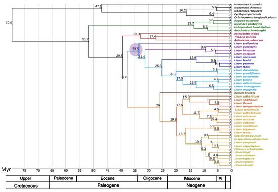

**Figure 4.** Bayesian chronogram of 45 taxa of Linaceae and 5 taxa of Ixonanthaceae. The values shown above branches are the dates of the nodes. The purple circle marks the point of the sect. Stellerolinum divergence from the common trunk of the blue-flowered flax. Pl on the geochronological scale—Pliocene.

## 3. Discussion

#### 3.1. The Reasons for Some Inconsistencies in Previous Phylogenetic Studies

In this work, as well as in our previous studies [10,11], we used a sample of L. stelleroides collected in the natural habitat in the Far East of Russia and grown in the Botanical Garden-Institute of the Far-Eastern Branch of the Russian Academy of Sciences (BGI FEB RAS) in Vladivostok, Russia. It has all the specific morphological characteristics inherent in the L. stelleroides species. Previously, we studied this sample using molecular karyological methods and found that its chromosome number is 2n = 20 [10], which completely agrees with the results of Sokolovskaya and Probatova [14]. In addition, the sequences of rbcL, the trnL–trnF spacer, ndhF, and ITS assembled from WGS reads of this specimen turned out to be highly homologous to the sequences of the same loci in the genomic DNA of herbarium samples [5].

Along with morphological and karyological similarities [3,10], closely related L. decumbens and L. grandiflorum showed a high degree of similarity between their rbcL, trnL–trnF spacer, 3’ trnK intron, ndhF, and ITS sequences [5]. The sequences of these loci assembled in this study proved to be highly homologous (>99%) to those obtained for herbarium samples [5]. At the same time, the sequences of trnG, the psbA–trnH spacer, and the rpl16 intron of L. grandiflorum (NCBI GenBank accessions GQ845264, GQ845291, and GQ845237 respectively) obtained from genomic DNA of the Tmp1200 seed accession (PGRC) [12] were more similar to the sequences of the same loci of the L. perenne group species than to those of L. decumbens and L. grandiflorum assembled from WGS reads. Thus, a seed sample of L. grandiflorum was likely confused with that of one of sect. Adenolinum members. Having assembled the examined loci from WGS reads of two yellow-flowered flax species —L. strictum and L. arboreum, we also found errors in the species identification of the plant samples. Thus, the WGS data for the specimen named L. strictum can belong to a member of the sect. Adenolinum. In the phylogenetic tree, this WGS data were clustered together with that of sect. Adenolinum members [9]. The WGS data for L. arboreum probably belongs to Alyssoides utriculata (L.) Medik. (Brassicaceae) or to a closely related species.

Thus, the analysis of both our data and the literature demonstrated that seed collections contain a significant number of samples with erroneous species identification. The correctness of the species identification of a studied plant specimen has to be re-examined before starting molecular genetic studies.

#### 3.2. Comparison of Our Results with Previous Phylogenetic Studies of Flax

The obtained ML and Bayesian trees in an initial nonclock analysis of the combined extant data set (Figure 2 and Figure 3) are largely in agreement with previous phylogenetic studies. At the same time, in the published phylogenies, we observed differences in the arrangement of L. stelleroides and L. grandiflorum inside the clade of the blue-flowered flax [5,6,7,8,9,10,11,12]. These differences are associated with erroneous species identification of the used L. stelleroides and L. grandiflorum samples. After eliminating these errors, the phylogenetic relationship between these species was clarified. L. stelleroides forms a basal branch of the blue-flowered flax clade, and L. grandiflorum is closely related to L. decumbens. The phylogenetic relationship in the clade of yellow-flowered flax species established in this study is also in good agreement with the previously obtained data. However, the phylogenetic relationship between sections Cathartolinum and Syllinum, as well as the members of the sect. Linopsis, is still not entirely clear. Since the data on genomic sequences of representatives of the yellow-flowered flax clade are currently highly limited, their genomes require further research using modern sequencing methods.

## 4. Materials and Methods

#### 4.1. Data Sources

To clarify the position of L. stelleroides in the phylogenetic tree of Linaceae, eight regions of chloroplast DNA (matK, ndhF, rbcL, the rpl16 intron, trnG, the psbA–trnH intergenic spacer, the 3’ trnK intron, and the trnL–trnF intergenic spacer) and three nuclear sequences (IGS and ITS1 + 5.8S rDNA + ITS2 of the 35S rRNA gene and the 5S rRNA gene) were analyzed in 50 plant species, representing an almost complete generic and sectional sampling of Linoideae. Four Hugonioideae species and five Ixonanthaceae species were taken as an external group. Examined plant species and the sources of the analyzed sequences are listed in Supplementary Table S12.

For the majority of the studied species, we used sequences from NCBI GenBank, obtained by PCR amplification followed by amplicon cloning and sequencing. Also, we took into the analysis sequences of 5S rRNA genes of the blue-flowered flax, which were previously determined using PCR amplification and subsequent high-throughput sequencing of amplicons [10]. Shotgun genomic sequencing data for 12 flax species (L. stelleroides, L. hirsutum, L. perenne, L. leonii, L. lewisii, L. narbonense, L. decumbens, L. grandiflorum, L. bienne (syn. L. angustifolium), L. usitatissimum, L. strictum, and L. arboreum) were derived earlier and deposited in NCBI SRA (BioProjects PRJNA262458 and PRJNA497747). Five flax samples representing L. stelleroides, L. hirsutum, L. perenne, L. narbonense, and L. usitatissimum species were sequenced within our BioProject PRJNA497747. In 2012, a number of accessions were grown in the field to verify the correctness of species identification, including L. hirsutum, L. perenne, and L. narbonense (each of the three was sequenced later), as well as LIN 1655 from Leibniz Institute of Plant Genetics and Crop Plant Research (Gatersleben, Germany) [11]. Considering the results of this test, we excluded the LIN 1655 accession from further studies and replaced it with the L. stelleroides specimen, the seeds of which were collected near the Kraskino village in Khasansky district of the Far East of Russia (natural habitat) and grown in the Botanical Garden-Institute FEB RAS, Vladivostok, Russia. As LIN 1655 continues to be actively used in various genomic studies, we decided to present here previously unpublished information regarding the morphology of this sample. For all 12 sequenced species, we performed a local reference-based assembly of orthologous loci suitable for further phylogenetic study using the CLC Genomics Workbench software (CLC bio, Aarhus, Denmark). We used the corresponding gene sequence of the same or closely related species obtained by cloning and sequencing of PCR products and deposited in GenBank as a reference for each of the studied loci. When creating consensus sequences for loci containing a SNP, the most common nucleotide variant was chosen. Intergenic spacer (IGS) sequences of the flax 35S rRNA genes were assembled with the TAREAN tool of RepeatExplorer2 [15] using the option “cluster merging”.

#### 4.2. Phylogenetic Analysis and Statistical Evaluation

The alignment of the analyzed sequences was performed using ClustalW [16] with the following parameters for Pairwise Sequence Alignment: Gap Opening Penalty—15, Gap Extension Penalty—6.66. The parameters for Multiple Sequence Alignment were: Gap Opening Penalty—15, Gap Extension Penalty—6.66, DNA Weight Matrix—JUB, Transition Weight—0.5, Delay Divergent Cutoff—70%.

A Bayesian analysis was performed using the GTR + I + G model. Prior probability distributions for all parameters were kept at default values, and all the parameters were unlinked between all partitions except for tree topology and branch lengths. MrBayes was run with Markov chains Monte Carlo (MCMC) analysis of four (one cold and three heated) chains, two runs, 4 million generations, sampling one tree in every 1000 generations. Node supports were assessed by the Bayesian-like modification of the approximate likelihood ratio test (aBayes) [21]. The Bayesian analysis was repeated twice.

Divergence times of Linaceae taxa were estimated using an uncorrelated log-normal relaxed clock model [19]. The general time-reversible model with gamma rate variation across sites (GTR + G) was preferred for all partitions. The time tree was calibrated by two points using total-evidence dating. The oldest known fossil pollen grains of Linum dated to 33.9–37.2 Ma [22]. The age of this fossil was calibrated as uniformly distributed inside the interval (33.9–37.2 Ma). The calibration of the tree age was based on the recent estimation of divergence time of Linaceae and Ixonanthaceae: 103.4–73.6 Ma [23]. To date the root of the tree, we used an offset exponential distribution with minimal age equal to 70 Ma and mean age equal to 90 Ma. The MCMC analysis of four chains with two independent runs was carried out until the average standard deviation of split frequencies became <0.01. The ML and Bayesian trees were visualized by the iTOL online tool (https://itol.embl.de/, accessed on 10 January 2022) [24].

## Supplementary Materials

The following supporting information can be downloaded at: https://www.mdpi.com/article/10.3390/plants11050652/s1, Table S1: Assembled sequences of IGS of the 35S rRNA gene; Table S2: Assembled sequences of ITS1 + 5.8S rDNA + ITS2 of the 35S rRNA gene; Table S3: Assembled sequences of the 5S rRNA gene; Table S4: Assembled sequences of matK; Table S5: Assembled sequences of ndhF; Table S6: Assembled sequences of rbcL; Table S7: Assembled sequences of the rpl16 intron; Table S8: Assembled sequences of trnG; Table S9: Assembled sequences of the psbA–trnH intergenic spacer; Table S10: Assembled sequences of the 3’ trnK intron; Table S11: Assembled sequences of the trnL–trnF intergenic spacer; Table S12: Sources of flax sequences used for the phylogenetic study: NCBI GenBank accessions and supplementary tables containing sequences assembled by us using high-throughput sequencing data.

## Author Contributions

Conceptualization, N.L.B.; investigation, N.L.B., N.V.M., E.M.D., L.N.M., O.Y.Y., A.V.A., G.S.K., A.A.D. and O.V.M.; writing, N.L.B., N.V.M., E.M.D., G.S.K. and A.A.D. All authors have read and agreed to the published version of the manuscript.

## Funding

The work was financially supported by the Ministry of Science and Higher Education of the Russian Federation, grant number 075-15-2021-1064.

## Institutional Review Board Statement

Not applicable.

## Informed Consent Statement

Not applicable.

## Data Availability Statement

The data presented in this study is contained within the article and Supplementary Materials.

## Acknowledgments

We thank Zoya Vital’evna Kozhevnikova, senior researcher at the Herbarium VLA of the Federal Scientific Center of the East Asia Terrestrial Biodiversity FEB RAS, Vladivostok, Russia, for providing the photo of L. stelleroides.

## Conflicts of Interest

The authors declare no conflict of interest.

## References

1. Rogers, C.M.; Xavier, K.S. Pollen morphology as an aid in determining relationships among some widely separated old world species of Linum. Grana **1971**, 11, 55–57. [Google Scholar] [[CrossRef](https://doi.org/10.1080/00173137109427412)]
2. Yuzepchuk, S.V. Genus Linum-Linaceae Dumort. In Flora SSSR (Flora of the Soviet Union); Shishkin, B.K., Bobrov, E.G., Eds.; Izdatel’stvo Akademii Nauk SSSR: Moscow, Russia, 1949; Volume 14, pp. 84–146. [[Google Scholar](https://scholar.google.com/scholar_lookup?title=Genus+Linum-Linaceae+Dumort&author=Yuzepchuk,+S.V.&publication_year=1949&pages=84%E2%80%93146)]
3. Ockendon, D.J.; Walters, S.M. Linaceae. In Flora Europaea. Rosacea to Umbelliferaceae; Tutin, T.G., Ed.; Cambridge University Press: Cambridge, UK, 1968; Volume 2, pp. 206–211. [[Google Scholar](https://scholar.google.com/scholar_lookup?title=%C2%A0Linaceae&author=Ockendon,+D.J.&author=Walters,+S.M.&publication_year=1968&pages=206%E2%80%93211)]
4. Quanru, L.; Zhou, L. Linaceae. In Flora of China. Oxalidaceae through Aceraceae; Wu, Z.Y., Raven, P.H., Eds.; Missouri Botanical Garden Press: St. Louis, MO, USA, 2008; Volume 11, pp. 34–38. [[Google Scholar](https://scholar.google.com/scholar_lookup?title=%C2%A0Linaceae&author=Quanru,+L.&author=Zhou,+L.&publication_year=2008&pages=34%E2%80%9338)]
5. McDill, J.; Repplinger, M.; Simpson, B.; Kadereit, J. The Phylogeny of Linum and Linaceae Subfamily Linoideae, with Implications for Their Systematics, Biogeography, and Evolution of Heterostyly. Syst. Bot. **2009**, 34, 386–405. [Google Scholar] [[CrossRef](https://doi.org/10.1600/036364409788606244)]
6. Fu, Y.B.; Dong, Y.; Yang, M.H. Multiplexed shotgun sequencing reveals congruent three-genome phylogenetic signals for four botanical sections of the flax genus Linum. Mol. Phylogenetics Evol. **2016**, 101, 122–132. [Google Scholar] [[CrossRef](https://doi.org/10.1016/j.ympev.2016.05.010)]
7. Fu, Y.-B.; Allaby, R.G. Phylogenetic network of Linum species as revealed by non-coding chloroplast DNA sequences. Genet. Resour. Crop Evol. **2010**, 57, 667–677. [Google Scholar] [[CrossRef](https://doi.org/10.1007/s10722-009-9502-7)]
8. Vromans, J. Molecular Genetic Studies in Flax (Linum Usitatissimum L.). Ph.D. Thesis, Wageningen University, Wageningen, The Netherlands, 2006. [Google Scholar]
9. Zhang, J.; Qi, Y.; Wang, L.; Wang, L.; Yan, X.; Dang, Z.; Li, W.; Zhao, W.; Pei, X.; Li, X.; et al. Genomic Comparison and Population Diversity Analysis Provide Insights into the Domestication and Improvement of Flax. iScience **2020**, 23, 100967. [Google Scholar] [[CrossRef](https://doi.org/10.1016/j.isci.2020.100967)]
10. Bolsheva, N.L.; Melnikova, N.V.; Kirov, I.V.; Speranskaya, A.S.; Krinitsina, A.A.; Dmitriev, A.A.; Belenikin, M.S.; Krasnov, G.S.; Lakunina, V.A.; Snezhkina, A.V.; et al. Evolution of blue-flowered species of genus Linum based on high-throughput sequencing of ribosomal RNA genes. BMC Evol. Biol. **2017**, 17, 253. [Google Scholar] [[CrossRef](https://doi.org/10.1186/s12862-017-1105-x)] [[PubMed](https://www.ncbi.nlm.nih.gov/pubmed/29297314)]
11. Melnikova, N.V.; Kudryavtseva, A.V.; Zelenin, A.V.; Lakunina, V.A.; Yurkevich, O.Y.; Speranskaya, A.S.; Dmitriev, A.A.; Krinitsina, A.A.; Belenikin, M.S.; Uroshlev, L.A.; et al. Retrotransposon-based molecular markers for analysis of genetic diversity within the genus Linum. BioMed Res. Int. **2014**, 2014, 231589. [Google Scholar] [[CrossRef](https://doi.org/10.1155/2014/231589)] [[PubMed](https://www.ncbi.nlm.nih.gov/pubmed/25243121)]
12. Schneider, A.C.; Freyman, W.A.; Guilliams, C.M.; Springer, Y.P.; Baldwin, B.G. Pleistocene radiation of the serpentine-adapted genus Hesperolinon and other divergence times in Linaceae (Malpighiales). Am. J. Bot. **2016**, 103, 221–232. [Google Scholar] [[CrossRef](https://doi.org/10.3732/ajb.1500379)] [[PubMed](https://www.ncbi.nlm.nih.gov/pubmed/26851267)]
13. Semenova, O.Y.; Samatadze, T.E.; Zelenin, A.V.; Muravenko, O.V. The comparative genome study of the species of Adenolinum and Stellerolinum sections by means of FISH technique. Biol. Membr. **2006**, 23, 453–460. [Google Scholar]
14. Sokolovskaya, A.P.; Probatova, N.S. Chromosome numbers in the vascular plants from the Primorye territory, Kamchatka, region Amur valley and Sakhalin. Bot. Zhurnal SSSR **1985**, 70, 997–999. [Google Scholar]
15. Novak, P.; Neumann, P.; Pech, J.; Steinhaisl, J.; Macas, J. RepeatExplorer: A Galaxy-based web server for genome-wide characterization of eukaryotic repetitive elements from next-generation sequence reads. Bioinformatics **2013**, 29, 792–793. [Google Scholar] [[CrossRef](https://doi.org/10.1093/bioinformatics/btt054)] [[PubMed](https://www.ncbi.nlm.nih.gov/pubmed/23376349)]
16. Thompson, J.D.; Higgins, D.G.; Gibson, T.J. CLUSTAL W: Improving the sensitivity of progressive multiple sequence alignment through sequence weighting, position-specific gap penalties and weight matrix choice. Nucleic Acids Res. **1994**, 22, 4673–4680. [Google Scholar] [[CrossRef](https://doi.org/10.1093/nar/22.22.4673)] [[PubMed](https://www.ncbi.nlm.nih.gov/pubmed/7984417)]
17. Guindon, S.; Dufayard, J.F.; Lefort, V.; Anisimova, M.; Hordijk, W.; Gascuel, O. New algorithms and methods to estimate maximum-likelihood phylogenies: Assessing the performance of PhyML 3.0. Syst. Biol. **2010**, 59, 307–321. [Google Scholar] [[CrossRef](https://doi.org/10.1093/sysbio/syq010)] [[PubMed](https://www.ncbi.nlm.nih.gov/pubmed/20525638)]
18. Huelsenbeck, J.P.; Ronquist, F. MRBAYES: Bayesian inference of phylogenetic trees. Bioinformatics **2001**, 17, 754–755. [Google Scholar] [[CrossRef](https://doi.org/10.1093/bioinformatics/17.8.754)] [[PubMed](https://www.ncbi.nlm.nih.gov/pubmed/11524383)]
19. Ronquist, F.; Huelsenbeck, J.P. MrBayes 3: Bayesian phylogenetic inference under mixed models. Bioinformatics **2003**, 19, 1572–1574. [Google Scholar] [[CrossRef](https://doi.org/10.1093/bioinformatics/btg180)] [[PubMed](https://www.ncbi.nlm.nih.gov/pubmed/12912839)]
20. Darriba, D.; Taboada, G.L.; Doallo, R.; Posada, D. jModelTest 2: More models, new heuristics and parallel computing. Nat. Methods **2012**, 9, 772. [Google Scholar] [[CrossRef](https://doi.org/10.1038/nmeth.2109)] [[PubMed](https://www.ncbi.nlm.nih.gov/pubmed/22847109)]
21. Anisimova, M.; Gil, M.; Dufayard, J.F.; Dessimoz, C.; Gascuel, O. Survey of branch support methods demonstrates accuracy, power, and robustness of fast likelihood-based approximation schemes. Syst. Biol. **2011**, 60, 685–699. [Google Scholar] [[CrossRef](https://doi.org/10.1093/sysbio/syr041)] [[PubMed](https://www.ncbi.nlm.nih.gov/pubmed/21540409)]
22. Cavagnetto, C.; Anadón, P. Preliminary palynological data on floristic and climatic changes during the Middle Eocene-Early Oligocene of the eastern Ebro Basin, northeast Spain. Rev. Palaeobot. Palynol. **1996**, 92, 281–305. [Google Scholar] [CrossRef]
23. Xi, Z.; Ruhfel, B.R.; Schaefer, H.; Amorim, A.M.; Sugumaran, M.; Wurdack, K.J.; Endress, P.K.; Matthews, M.L.; Stevens, P.F.; Mathews, S.; et al. Phylogenomics and a posteriori data partitioning resolve the Cretaceous angiosperm radiation Malpighiales. Proc. Natl. Acad. Sci. USA **2012**, 109, 17519–17524. [Google Scholar] [[CrossRef](https://doi.org/10.1073/pnas.1205818109)] [[PubMed](https://www.ncbi.nlm.nih.gov/pubmed/23045684)]
24. Letunic, I.; Bork, P. Interactive tree of life (iTOL) v3: An online tool for the display and annotation of phylogenetic and other trees. Nucleic Acids Res. **2016**, 44, W242–W245. [Google Scholar] [[CrossRef](https://doi.org/10.1093/nar/gkw290)] [[PubMed](https://www.ncbi.nlm.nih.gov/pubmed/27095192)]

|  | **Publisher’s Note:** MDPI stays neutral with regard to jurisdictional claims in published maps and institutional affiliations. |
| --- | --- |

© 2022 by the authors. Licensee MDPI, Basel, Switzerland. This article is an open access article distributed under the terms and conditions of the Creative Commons Attribution (CC BY) license (https://creativecommons.org/licenses/by/4.0/).

*[Plants](https://www.mdpi.com/journal/plants)*, EISSN 2223-7747, Published by MDPI Disclaimer